# Distribution of REs and RETEs

Steve Pederson & Lu Zeng

17 February 2016

# Load the packages and the data

```r
library(ggplot2)
library(MASS)
library(matrixStats)
library(xtable)
library(multcomp)
library(sandwich)
library(boot)
library(dplyr)
library(reshape2)
library(readr)
library(knitr)
library(magrittr)
library(limma)
library(spShortcuts)
library(car)
library(grid)
```

# Introduction

This script:

- Uses proportions transformed to the logit scale
- Tests for normality of data and homoscedasticity (i.e. equal variance across samples)
- Analyses the data using $p(TE\mid RE)$
- Generates Figure 2 & Table S1

```r
fig2 <- file.path("data", "Figure2.csv") %>%
  read_csv(col_names = FALSE) %>%
  set_colnames(c("Region", "RE", "Tissue", "bpRETE", "bpRE")) %>%
  mutate(Region = gsub("([35])'UTR", "UTR\\1", Region),
         Region = gsub("CDS-", "CDS", Region),
         Region = factor(Region, levels=c("UTR5", "CDSexon", "CDSintron",
                                          "UTR3", "Intergenic")),
         RE = gsub("Repressor", "Repressed_region", RE),
         RE = factor(RE, levels= c("Active_promoter","Weak_promoter", "Strong_enhancer",
                                   "Weak_enhancer", "Repressed_region", "Insulator")),
         Tissue = as.factor(Tissue),
         bpRETE = bpRETE / 100,
         bpRE = bpRE/100,
         `bpTE|RE` = bpRETE / bpRE,
         logitRETE = logit(bpRETE),
         logitRE = logit(bpRE),
         `logitTE|RE` = logit(`bpTE|RE`))
```

# Raw Data

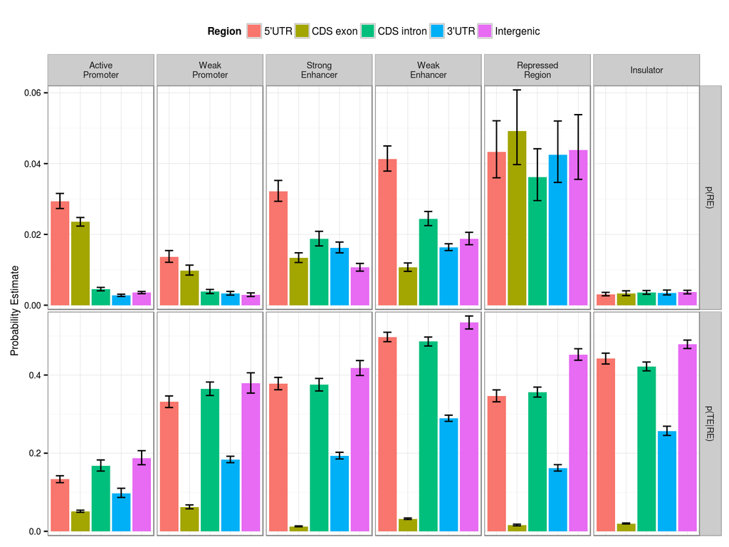

The estimated probabilities of a base being a Regulatory Element with each genomic region, and the estimated probabilities of a base within each Regulatory Element being a Transposable Element. Error bars indicate one standard error.

# Analysis of conditional probabilities

First an initial model was specified for the conditional probabilities, including interaction terms between each region and each RE.

```r
lmCond <- lm(`logitTE|RE` ~ Region*RE, fig2)
```

The Shapiro-Wilk Test was used to assess normality, and this assumption was not violated.

```r
lmCond %>%
  resid() %>%
  shapiro.test()
```

```
##
##  Shapiro-Wilk normality test
##
## data:  .
## W = 0.99225, p-value = 0.4513
```

Levene’s Test was performed to assess heteroscedasticity

```r
lmCond %>%
  leveneTest(center = "mean")
```

```
## Levene's Test for Homogeneity of Variance (center = "mean")
##        Df F value   Pr(>F)
## group  29  2.4388 0.000265 ***
##       150
## ---
## Signif. codes:  0 '***' 0.001 '**' 0.01 '*' 0.05 '.' 0.1 ' ' 1
```

As this assumption has been violated, all standard errors will be calculated using the sandwich estimator.

```r
resLmCond <- lmCond %>%
  glht(vcov = sandwich) %>%
  summary(test = adjusted("none")) %>%
  extract2("test") %>%
  extract(c("coefficients", "sigma", "tstat", "pvalues")) %>%
  as.data.frame() %>%
  add_rownames("Coefficient") %>%
  rename(Estimate = coefficients,
         `Std. Error` = sigma,
         T = tstat,
         P = pvalues) %>%
  mutate(Coefficient = gsub("(Region|RE)", "", Coefficient),
         Coefficient = gsub("_", " ", Coefficient),
         Coefficient = capwords(Coefficient),
         Coefficient = gsub("Utr(3|5)", "\\1'UTR", Coefficient),
         Coefficient = gsub("Cds", "CDS-", Coefficient),
         Coefficient = gsub(":(.)", ":\\U\\1", Coefficient, perl = TRUE),
         adjP = p.adjust(P, "bonferroni"),
         ` ` = aster(adjP))
```

Results from analysis of conditional probabilities across all regulatory elements and genomic regions using a linear regression model. The values being analysed are the logit transformed proportions of bases, such that a positive value corresponds to an increase in probability. Bonferroni’s adjustment has been applied to adjusted $p$-values, and the sandwich estimator was utilised for robust standard error estimation. Asterisks indicate significance as per the standard conventions of R

| Coefficient | Estimate | Std. Error | T | P | adjP |  |
| --- | --- | --- | --- | --- | --- | --- |
| (intercept) | -1.873 | 0.0697 | -26.866 | 0.00e+00 | 0.00e+00 | *** |
| CDS-exon | -1.043 | 0.0860 | -12.134 | 0.00e+00 | 0.00e+00 | *** |
| CDS-intron | 0.273 | 0.1160 | 2.355 | 1.98e-02 | 5.95e-01 |  |
| 3’UTR | -0.349 | 0.1403 | -2.484 | 1.41e-02 | 4.22e-01 |  |
| Intergenic | 0.409 | 0.1283 | 3.184 | 1.77e-03 | 5.30e-02 | . |
| Weak Promoter | 1.172 | 0.0926 | 12.657 | 0.00e+00 | 0.00e+00 | *** |
| Strong Enhancer | 1.375 | 0.0927 | 14.832 | 0.00e+00 | 0.00e+00 | *** |
| Weak Enhancer | 1.863 | 0.0824 | 22.598 | 0.00e+00 | 0.00e+00 | *** |
| Repressed Region | 1.239 | 0.0929 | 13.345 | 0.00e+00 | 0.00e+00 | *** |
| Insulator | 1.640 | 0.0865 | 18.962 | 0.00e+00 | 0.00e+00 | *** |
| CDS-exon:Weak Promoter | -0.966 | 0.1319 | -7.323 | 1.38e-11 | 4.13e-10 | *** |
| CDS-intron:Weak Promoter | -0.127 | 0.1475 | -0.860 | 3.91e-01 | 1.00e+00 |  |
| 3’UTR:Weak Promoter | -0.441 | 0.1609 | -2.742 | 6.86e-03 | 2.06e-01 |  |
| Intergenic:Weak Promoter | -0.199 | 0.1742 | -1.145 | 2.54e-01 | 1.00e+00 |  |
| CDS-exon:Strong Enhancer | -2.812 | 0.1322 | -21.277 | 0.00e+00 | 0.00e+00 | *** |
| CDS-intron:Strong Enhancer | -0.285 | 0.1453 | -1.964 | 5.13e-02 | 1.00e+00 |  |
| 3’UTR:Strong Enhancer | -0.580 | 0.1610 | -3.601 | 4.30e-04 | 1.29e-02 | * |
| Intergenic:Strong Enhancer | -0.242 | 0.1593 | -1.520 | 1.31e-01 | 1.00e+00 |  |
| CDS-exon:Weak Enhancer | -2.350 | 0.1111 | -21.159 | 0.00e+00 | 0.00e+00 | *** |
| CDS-intron:Weak Enhancer | -0.320 | 0.1309 | -2.442 | 1.58e-02 | 4.73e-01 |  |
| 3’UTR:Weak Enhancer | -0.540 | 0.1512 | -3.571 | 4.77e-04 | 1.43e-02 | * |
| Intergenic:Weak Enhancer | -0.260 | 0.1487 | -1.748 | 8.25e-02 | 1.00e+00 |  |
| CDS-exon:Repressed Region | -2.438 | 0.1584 | -15.395 | 0.00e+00 | 0.00e+00 | *** |
| CDS-intron:Repressed Region | -0.231 | 0.1407 | -1.641 | 1.03e-01 | 1.00e+00 |  |
| 3’UTR:Repressed Region | -0.659 | 0.1628 | -4.051 | 8.17e-05 | 2.45e-03 | ** |
| Intergenic:Repressed Region | 0.035 | 0.1523 | 0.229 | 8.19e-01 | 1.00e+00 |  |
| CDS-exon:Insulator | -2.617 | 0.1155 | -22.660 | 0.00e+00 | 0.00e+00 | *** |
| CDS-intron:Insulator | -0.355 | 0.1337 | -2.656 | 8.76e-03 | 2.63e-01 |  |
| 3’UTR:Insulator | -0.480 | 0.1596 | -3.008 | 3.09e-03 | 9.26e-02 | . |
| Intergenic:Insulator | -0.261 | 0.1437 | -1.817 | 7.12e-02 | 1.00e+00 |  |

# Confidence Intervals

In order to make comparisons between $p(TE \mid RE)$ estimates by region and element, a matrix of pair-wise comparisons was formed manually.

```r
modMat <- lmCond %>%
  update(.~. -1) %>%
  model.matrix
colnames(modMat) <- gsub("(Region|RE)", "", colnames(modMat))
colnames(modMat) <- gsub(":", ".", colnames(modMat))
contMat <- list(
  `Active Promoter` = makeContrasts(
    CDSexon - UTR5,
    CDSexon - CDSintron,
    CDSexon - UTR3,
    CDSexon - Intergenic,
    UTR3 - UTR5,
    UTR3 - Intergenic,
    UTR3 - CDSintron,
    Intergenic - UTR5,
    Intergenic - CDSintron,
    CDSintron - UTR5,
    levels = modMat),
  `Weak Promoter` = makeContrasts(
    CDSexon + CDSexon.Weak_promoter - UTR5,
    CDSexon + CDSexon.Weak_promoter -  CDSintron - CDSintron.Weak_promoter,
    CDSexon + CDSexon.Weak_promoter - UTR3 - UTR3.Weak_promoter,
    CDSexon + CDSexon.Weak_promoter - Intergenic - Intergenic.Weak_promoter,
    UTR3 + UTR3.Weak_promoter - UTR5,
    UTR3 + UTR3.Weak_promoter - Intergenic - Intergenic.Weak_promoter,
    UTR3 + UTR3.Weak_promoter -  CDSintron - CDSintron.Weak_promoter,
    Intergenic + Intergenic.Weak_promoter - UTR5,
    Intergenic + Intergenic.Weak_promoter - CDSintron - CDSintron.Weak_promoter,
    CDSintron + CDSintron.Weak_promoter - UTR5,
    levels = modMat),
  `Strong Enhancer` = makeContrasts(
    CDSexon + CDSexon.Strong_enhancer - UTR5,
    CDSexon + CDSexon.Strong_enhancer -  CDSintron - CDSintron.Strong_enhancer,
    CDSexon + CDSexon.Strong_enhancer - UTR3 - UTR3.Strong_enhancer,
    CDSexon + CDSexon.Strong_enhancer - Intergenic - Intergenic.Strong_enhancer,
    UTR3 + UTR3.Strong_enhancer - UTR5,
    UTR3 + UTR3.Strong_enhancer - Intergenic - Intergenic.Strong_enhancer,
    UTR3 + UTR3.Strong_enhancer -  CDSintron - CDSintron.Strong_enhancer,
    Intergenic + Intergenic.Strong_enhancer - UTR5,
    Intergenic + Intergenic.Strong_enhancer - CDSintron - CDSintron.Strong_enhancer,
    CDSintron + CDSintron.Strong_enhancer - UTR5,
    levels = modMat),
  `Weak Enhancer` = makeContrasts(
    CDSexon + CDSexon.Weak_enhancer - UTR5,
    CDSexon + CDSexon.Weak_enhancer -  CDSintron - CDSintron.Weak_enhancer,
    CDSexon + CDSexon.Weak_enhancer - UTR3 - UTR3.Weak_enhancer,
    CDSexon + CDSexon.Weak_enhancer - Intergenic - Intergenic.Weak_enhancer,
    UTR3 + UTR3.Weak_enhancer - UTR5,
    UTR3 + UTR3.Weak_enhancer - Intergenic - Intergenic.Weak_enhancer,
    UTR3 + UTR3.Weak_enhancer -  CDSintron - CDSintron.Weak_enhancer,
    Intergenic + Intergenic.Weak_enhancer - UTR5,
    Intergenic + Intergenic.Weak_enhancer - CDSintron - CDSintron.Weak_enhancer,
    CDSintron + CDSintron.Weak_enhancer - UTR5,
    levels = modMat),
  `Repressed Region` = makeContrasts(
    CDSexon + CDSexon.Repressed_region - UTR5,
    CDSexon + CDSexon.Repressed_region -  CDSintron - CDSintron.Repressed_region,
    CDSexon + CDSexon.Repressed_region - UTR3 - UTR3.Repressed_region,
    CDSexon + CDSexon.Repressed_region - Intergenic - Intergenic.Repressed_region,
    UTR3 + UTR3.Repressed_region - UTR5,
    UTR3 + UTR3.Repressed_region - Intergenic - Intergenic.Repressed_region,
    UTR3 + UTR3.Repressed_region -  CDSintron - CDSintron.Repressed_region,
    Intergenic + Intergenic.Repressed_region - UTR5,
    Intergenic + Intergenic.Repressed_region - CDSintron - CDSintron.Repressed_region,
    CDSintron + CDSintron.Repressed_region - UTR5,
    levels = modMat),
  `Insulator` = makeContrasts(
    CDSexon + CDSexon.Insulator - UTR5,
    CDSexon + CDSexon.Insulator -  CDSintron - CDSintron.Insulator,
    CDSexon + CDSexon.Insulator - UTR3 - UTR3.Insulator,
    CDSexon + CDSexon.Insulator - Intergenic - Intergenic.Insulator,
    UTR3 + UTR3.Insulator - UTR5,
    UTR3 + UTR3.Insulator - Intergenic - Intergenic.Insulator,
    UTR3 + UTR3.Insulator -  CDSintron - CDSintron.Insulator,
    Intergenic + Intergenic.Insulator - UTR5,
    Intergenic + Intergenic.Insulator - CDSintron - CDSintron.Insulator,
    CDSintron + CDSintron.Insulator - UTR5,
    levels = modMat)

)
for (i in 2:6) colnames(contMat[[i]]) <- colnames(contMat[[1]])
```

As there were 6 regulatory elements under investigation, $1- \alpha$ Confidence Intervals were generated within each RE using the package `multcomp`. These intervals will control the FWER at a given level within each RE, thus $\alpha = 0.05 / 6$ was set for each RE.

```r
confintCond <- names(contMat) %>%
  lapply(function(x){
    lmCond %>%
      update(.~. -1) %>%
      glht(vcov = sandwich, linfct = t(contMat[[x]])) %>%
      confint(level = 1 - 0.05/6) %>%
      extract2("confint") %>%
      as.data.frame() %>%
      add_rownames(var = "Comparison") %>%
      mutate(RE = x)
  }) %>%
  bind_rows %>%
  mutate(Sig = sign(lwr) == sign(upr),
         RE = factor(RE, levels = unique(RE)),
         Comparison = factor(Comparison, levels = unique(Comparison)))
```

These Confidence Intervals were then plotted across the set of REs.

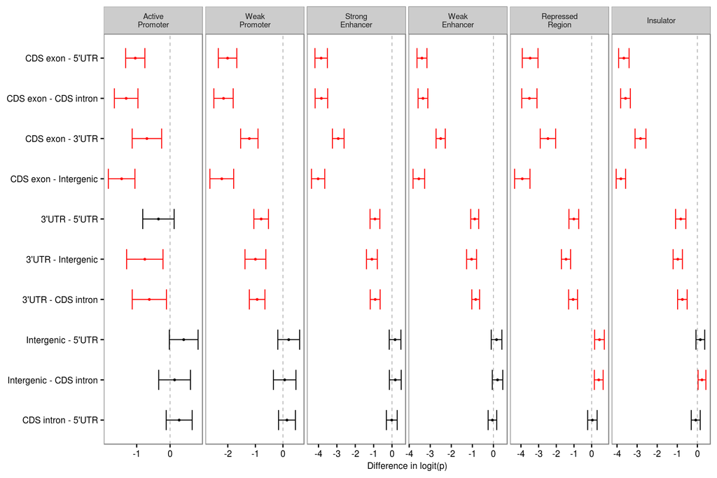

FWER-adjusted 95% Confidence Intervals for the difference in probabilities. Intervals which do not contain zero are coloured red, indicating a rejection of the null hypothesis that there is no difference between these two probabilities.

## Export the final combined figure